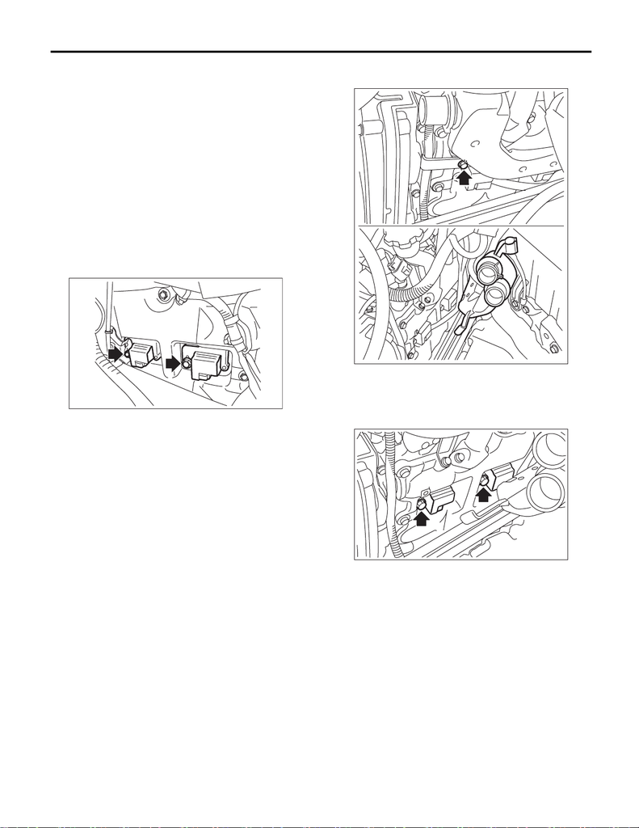

Spark Plug

IGNITION

2. Spark Plug

A: REMOVAL

Spark plug:

Refer to “SPECIFICATION” for the spark

plug. <Ref. to IG(STI)-2, SPECIFICATION,

General Description.>

1. RH SIDE

1) Disconnect the ground cable from battery.

2) Remove the air cleaner case. <Ref. to IN(STI)-9,

REMOVAL, Air Cleaner Case.>

3) Disconnect the connector from ignition coil.

4) Remove the ignition coil.

NOTE:

Turn #3 ignition coil by 180° to remove it.

5) Remove the spark plug with a spark plug socket.

2. LH SIDE

1) Remove the battery. <Ref. to SC(STI)-21, RE-

MOVAL, Battery.>

2) Remove the secondary air pump. <Ref. to

EC(STI)-53, REMOVAL, Secondary Air Pump.>

3) Remove the bolts that secure the air duct to the

rocker cover LH, and lift the air duct.

4) Disconnect the connector from ignition coil.

5) Remove the ignition coil.

NOTE:

Turn #4 ignition coil by 180° to remove it.

6) Remove the spark plug with a spark plug socket.

IG-02127

IG-02072

IG-02149

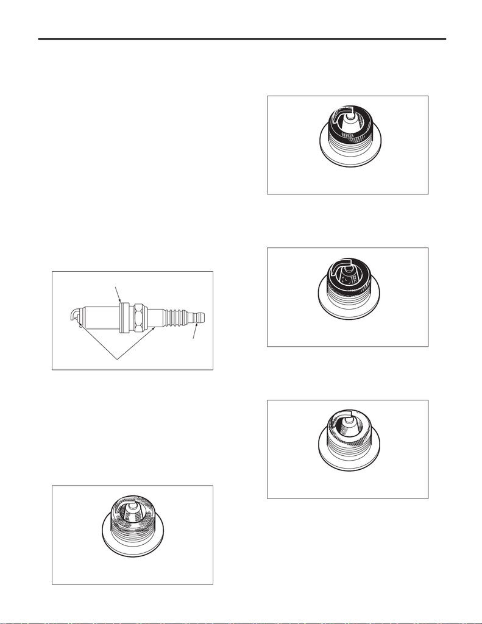

Spark Plug

IGNITION

B: INSTALLATION

1. RH SIDE

Install in the reverse order of removal.

Tightening torque (Spark plug):

21 N·m (2.1 kgf-m, 15.5 ft-lb)

Tightening torque (Ignition coil):

16 N·m (1.6 kgf-m, 11.8 ft-lb)

2. LH SIDE

Install in the reverse order of removal.

Tightening torque (Spark plug):

21 N·m (2.1 kgf-m, 15.5 ft-lb)

Tightening torque (Ignition coil):

16 N·m (1.6 kgf-m, 11.8 ft-lb)

Tightening torque (Air duct):

6.4 N·m (0.7 kgf-m, 4.7 ft-lb)

C: INSPECTION

1) Check the spark plug for abnormalities. If defec-

tive, replace the spark plug.

2) Check the spark plug electrode and condition of

the insulator. If abnormal, check and repair the

cause and replace the spark plug.

(1) Normal:

Brown to grayish-tan deposits and slight elec-

trode wear indicate correct spark plug heat

range.

(2) Carbon fouled:

Dry fluffy carbon deposits on insulator and elec-

trode are mostly caused by slow speed driving

in the city, weak ignition, too rich fuel mixture,

etc.

(3) Oil fouled:

Wet black deposits show oil entrance into com-

bustion chamber through worn piston rings or

increased clearance between valve guides and

valve stems.

(4) Overheating:

A white or light gray insulator with black or

brown spots and bluish burnt electrodes indi-

cate engine overheating, wrong selection of fu-

el, or loose spark plugs.

(A) Terminal damage

(B) Crack or damage in insulator

(C) Damaged gasket

IG-02094

(C)

(A)

(B)

IG-00011

IG-00012

IG-00013

IG-00014

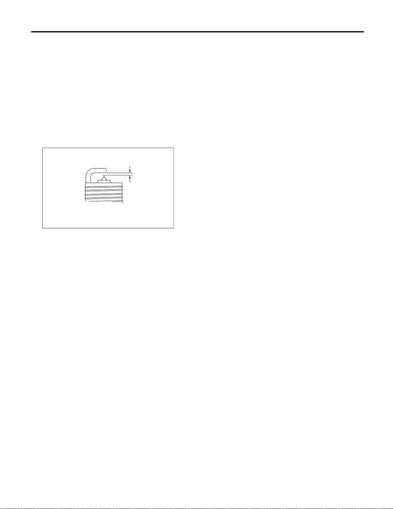

Spark Plug

IGNITION

3) Using a nylon brush, etc., clean and remove the

carbon or oxide deposits from the spark plug. If de-

posits are too stubborn, replace the spark plugs.

After cleaning the spark plugs, check the spark

plug gap “L” using a gap gauge. If it is not within the

standard, replace the spark plug.

NOTE:

• Never use a plug cleaner.

• Do not use a metal brush as it may damage the

electrode area.

Spark plug gap L:

Standard

0.7 — 0.8 mm (0.028 — 0.031 in)

IG-02095

L